# Notes on Information Technology and System-Level Political Contention

Justin Murphy

November 13, 2014

# Part 1: The Puzzle and General Theoretical Reflections

## Fragments

In the 1960s there was massive and widespread *system-level* political contention in many countries around the world.[^1]

To document and explain this surprisingly under-reported empirical puzzle, I will make a series of arguments that focus on the nature of information in politics. These arguments lead to the following argument, which will of course require some effort to adequately unpack. I will argue that the information revolution led to an uneven but worldwide shift in ethical and behavioral orientations. By increasing the payoffs to instrumental rationality (exploitative human action based on maximizing efficiency of means) relative to substantial rationality (honest/dialectical/cooperative action driven by ultimate goals), individuals and organizations with exploitative ethics were significantly more empowered by the information revolution than those with cooperative ethics. In a process of incentivized learning, there was a massive defection from substantial rationality (and system-level political contention against institutions and for human liberation from the domination of institutions) to instrumental rationality (individual-level adjustment to institutions).

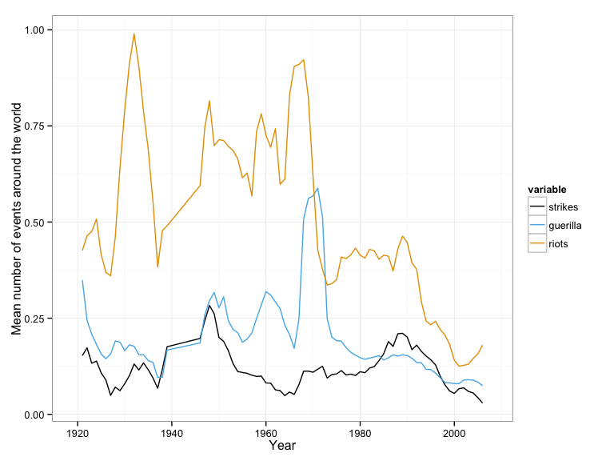

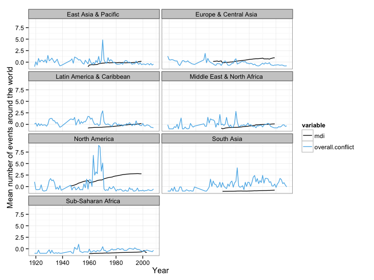

The conventional wisdom for explaining this shift is that the contention of the mid-century was directed mostly toward colonial oppressors and authoritarian regimes, so that all of this militant contention dissipated simply because decolonization and democratization gave people what they wanted: freedom from colonialism and democracy. This is, of course, one way to read the history. But objectively, there is a huge problem for this conventional wisdom, which mainstream social scientists will not even touch, and indeed they *cannot* even touch it without revealing the bad faith behind almost all of their concepts. That objective problem is that decolonization on the whole did not give way to robust national independence for the formerly colonized peoples and democratization on the whole did not lead to democratic governments. All of the most powerful genuine democratic (typically socialist) surges were aggressively thwarted by conservative interests, often with some amount of cooperation from the United States and its partner countries. To name the most well-known cases: Mossadegh in Iran 1953, Árbenz in Guatemala 1954, Qasim in Iraq 1960-63, Lumumba in Congo 1961, Ngô Đình Diệm in Vietnam 1963, Allende in Chile 1970-1973, the Communist party in Afghanistan 1979-89, Sandanista in Nicaragua 1981-1990.)

In this light, the processes of decolonization and “democratization” rarely if ever led to substantially new and improved national periods of political-economic satisfaction. While there were no doubt significant changes in the institutional distribution of powers within and across countries, it really just doesn’t objectively play out as a shift from oppression to liberation; rather it really seems much more like the shift from one type of equilibrium to a very different kind of equilibrium, but one which continues to be characterized by massive political and economic oppression.

## Instrumental and Substantial Communication

There’s a crucial distinction, emphasized in particular by the Frankfurt School, between instrumental and substantive rationality. Broadly, instrumental rationality is that type of rationality concerned with calculating means to ends and substantive rationality is that type of rationality concerned with understanding the whole (means and ends). Instrumental rationality is concerned with strategy, calculating how to get *anywhere* the most efficiently, whereas substantive rationality is concerned with trying to figure out where one should go in general.

The distinction emerges over and over again in politics.

- the personal integrity of anarchism vs the instrumentalism of marxism
- ethos and elan vs a separate realm of strategy (that is, even activists notion of “goal, strategy, tactics” begs the key questions of how to live and therefore simply skips precisely to the battlefield in which it has already been crushed)

Because the public sphere has been so completely subordinated to instrumentalism—the only speech which is even sensible is that which meets some minimal threshold of self-interest, because nothing else is credible—the most preliminary efforts to establish a genuinely kind and loving contact with another human being are basically impossible—let alone build radical ties or a social movement! This extraordinary change, and undeniable *decay* in communications has never before been fully identified, let alone explained. This also explains why today all currently existing social movements are completely unable to build anything which can even pretends to challenge the dominant institutions.

Instrumental communication is a means to some end which is not communicated in the message. That which seeks to make the receiver do something at the cost of some transparency (treats them as a means to an end; the first goal is to achieve something for the speaker’s interests).

non-instrumental communication is an end in itself which the communicator says for no reason other than whatever satisfactions are brought by saying it. Or importantly, if there is a larger end to speaking it, this is included in the message. Non-instrumental communication therefore treats the receiver as an end in themself, because the only instrumental value the communication can bring is through the autonomous action of the receiver after learning transparently the contents of the message.

They are perhaps never fully one or the other, but the argument here does not require absolute purity. It is enough to mark out objectively the consistent markers of the one and other. There has always been a conflict between instrumental communication and non-instrumental (let’s call it sincere) communication. Typically, historically, instrumental communication is the communication of the relatively powerful and sincere communication is the communication of the powerless; additionally, instrumental communication is the communication of the powerful as well as the powerless in spaces and times relatively characterized by power struggle (in a job interview, for instance, where someone is obviously and consciously involved in a competition to win the means to sustain one’s life), whereas sincere communication is the communication of all people in spaces and times relatively insulated from power struggles (with loved ones, for instance). While these types of communication have always co-existed, for most of human history they have been in equilibrium. Before the printing press, ruling elites in any particular society did not have an advantage in exercising instrumental communication over their subjects. They had symbolic machinery no doubt, but the subjects had what since time immemorial has been the most powerful communicative structure: being socially embeded among others in a concretely shared, if rarely equal, co-production of life. Indeed, to this day, it is known very well that one’s attitudes and behaviors are most crucially shaped by one’s “primary group,” precisely the individuals by whom one is surrounded on a day-to-day basis. Thus, the instrumental communications of the powerful have always been held in check by structures within which sincere communication prevailed. The lies of kings might have been obeyed because the balance of power forced subjects to accept them, but the history of human society shows amply that wherever domination prevails there also prevails the wisdom of the relatively weak who, sometimes laughing and sometimes crying and sometimes in silent gestures, always ultimately are the only bulwark which refutes the self-interested communications of the dominant.

However, since the industrial revolution, profound changes have occurred in this communicative balance of power.

In periods where the ability for a particular source to reach many people increases, there is always a sudden appearance of revolutionary political communication and revolutionary political upheaval. But after this opening, that which was so powerful for the forces of sincerity is exploited for instrumental purposes. While anyone can pursue their instrumental purposes after a sudden increase in the ability to reach people, almost by definition the most powerful will be able to spread their instrumental communications more widely than the less powerful.

(always quicker to the punch precisely because that which is sincere and organic is always waiting to explode, whereas that which strategically manipulates can only respond, hence we call this “reactionary”.)

#### 1820-1875 first upturn of globalization

telegraph, newspapers, amateur radio first international, revolutionary upsurges, Fanelli goes to Spain

#### 1875-1914 down turn of globalization

recuperations within the left, state-corporate control of radio, second international, anarchist terrorism as last gasping breathe. watering down of “democracy” as republicanism in 1875. ww1 as corporate-state lockdown. bolshevism.

#### 1949-1975 upturn of second globalization (without people)

trade, mass media internationally, anti-colonial war, information revolution about 1950.

#### 1975-1991 downturn of second globalization (without people)

neoliberalism, mass media solidification, trade and investment integration, collapse of soviet instrumentalism, mass evactuation of left sincerity in favor of left instrumentalism within capitalism.

#### 1994-2011 upturn of the networked world

zapatistas up to arab spring and occupy, flowerings of sincerity.

#### 2011-Today downturn of the networked world, the pacified world

capitalism as mainstream ideology of most people rich and poor, left and right. the main ideological cleavage is between ruthless instrumentalism and humane instrumentalism, but the pole of sincere, substantive ethical and political truth opposed to instrumentalism has been vanquished from most of the globe. the internet.

### How Instrumental Rationality Favors the Right and Inhibits the Left

The problem of most left political thought and practice since time immemorial is that, because they are generated precisely by exploitative institutional arrangements, the only left messages which receive recognition within such cultures are those which respond to the material needs of the exploited. This is perfectly understandable, because the material needs which sustain life are both ethically and practically prior to any possible social movement on other grounds. This is why normatively lofty or aesthetically-driven currents of leftist political thought and practice are always mocked in every period: when some people are starving, rhetorical flights of any sort do *seem* to reflect mistaken priorities. Thus it is that mature and decent leftists always tend to discipline the younger more “idealistic” leftists into calming their normative and rhetorical passions in favor of the hard work of getting material gains for the most exploited people. While this is perfectly understandable and quite natural to sympathize with, there is an extraordinary problem with this tendency. Specifically, it grants to the exploitative institutional arrangements their most crucial ethical and epistemological assumption: instrumental rationality. It is necessary for the exploited to practice the instrumental rationality required for survival, but the problem is that because of this need, the left capitulates *in general* to instrumental rationality as the proper analytical orientation to social and political struggle. Anything which opposes instrumental rationality is, to the committed and *rational* leftist, a prodigal self-indulgence of an immature and “privileged” soul uneducated in the history of the Practical Left.

Nevermind that the history of the Practical Left is a history of betrayal, capitulation, and ultimately, complete failure—given that domination and exploitation not only continue to exist but in the institutions of global capitalism institutionalized more powerfully than ever before in the history of humanity.

## skill-biased technological change

One reason is that improvements in information are a type of “skill-biased technological change” in which the relatively more educated see their power increase more than the less educated, but this is not unique to information technology. The crucial and unique implication is that, at least within market societies, advancements in information-processing bias all social communication toward status quo assumptions. Despite the widespread belief that new information technologies enhance democracy and cooperation, I argue that in the long-run, improvements in information-processing increase the profitability of instrumental or exploitative communication relative to cooperative or goal-driven communication. This is because those most invested in the status quo will use advancements in information-processing to advance themselves within the status quo rather than change the status quo as such; this forces those who would otherwise seek to change the status quo to speak and behave in agreement with the assumptions of the status quo in order to survive. While such a dynamic emerges for many types of technological innovation, only improvements in information-processing have such unique and far-reaching negative externalities on the public sphere because, while skill-biased technological change in industry might lead some workers to earn more in the factor, skill-biased change in information-processing leads some individuals to earn more from everyone in their life in general. For these reasons, the information revolution sparked a process in which all communication around the world is increasingly only instrumental communication, and the substantial communication required for individuals and communities to challenge elites is increasingly evacuated. This accounts for why, today, nearly all dominant political categories ring hollow, diverse types of social trust are depleted, and militant political resistance to the status quo has been pacified and erased from memory in the short span of about thirty years.

### The conservatism of everyday speech

(Rephrase because this is in pamphlet.)

Everyday words do not communicate, they are much better understood oppositely: they are blockages of communication, evolved to divide, channel, distort, and otherwise institutionalize the human community to increase utility of the most powerful groups. It is one of the largest and most powerful set of mechanisms for maintaining capitalism because they are the million little signposts which at every moment point to people which roads pay. At every fork in our road, at those specific moments when we do have the resources to choose good or evil, words always send us toward capitalism because words (logos) at best are merely true (a car which doesn’t come with an engine, let alone fuel). Logic and reason are motion-neutral, “disinterested” objective analysis cannot tell anyone what to value, as only subjective desire and commitment can propel and direct a person’s projects — but in a dynamic system *defined by* the instrumental exploitation of humans, then disinterested logos and ratio is exploitation. Strong logical reasoning is always paid because good thinking always strays and is always at risk of overthrowing the status quo. Words provide the service of absorbing a society’s cognitive capacities into channels which prevent volatile shifts of group movement. And we are simply paid to use those words which absorb or mystify or deflect human desire into a desire for capitalism. We earn nothing if we use words which fail to channel human desire into exploitation, and finally we are punished to the degree our words challenge or inconvenience powerful actors.

### Economic premium to computational thinking

A huge problem with the information age is that because computational skills are rewarded disproportionately, and the top calculator minds quickly become privileged by the status quo, what comes to be counted and calculated tends to be motivated by a blithe confidence and satisfaction with the institutions of the status quo.

### Principled Contentious Action

We might call “principled contentious action” anti-institutional or anti-systemic political behaviors grounded in truth claims this is what has been pacified there are still some contentious uprisings and there are still people making truth claims but these have been separated, and that is the crucial mystification which defines our world. but zola was also very strategic, how is that different than today? being strategic in a principled campaign is different than today, which is generating principles to serve strategic ends. in the former, ends are sincere but the means are strategic. in the latter, means are sincere but the ends are dishonest. zola took radical strategic action in pursuit of forcing truth and justice, even if he did it strategically; non-profit organizations use claims of truth and justice as a vehicle for strategically promoting certain groups.

### Understanding the nature of commercial bias

mass media have not programmed people to think or act in a certain way, they simply disconnect popular *resistance* from the reality of political affairs

the mechanism through which they do this is simply giving people what they want to hear and see. this is acknowledged by every media scholar to be a fundamental fact of commercial media. but it’s effect is to create “noise” in the democratic mechanism whereby people positively or negatively to political affairs. Because by definition people are receiving what they want, the bias is not left or right but rather media are biased in favor of system-level dynamics and against within-system dynamics. This is how we can account for the perplexity that people often think the media is TOO critical of politicians AND that it is not critical enough.

but it’s not just noise in the sense of random noise, it is by definition reinforcing of what they already think and feel and believe. this sounds like it might push radicals to be more radical and conservatives to be more conservative but this is wrong. why? because of a fundamental assymetry between left and right, which spatial models of politics fail to account for.

summarize the spatial model. that’s useful but quite poor in a key respect.

the right is whatever political reality is. the left is the desire to change the status quo to bring it more in line with justice. the right is that the status quo is justice and the change they promote is to stop those efforts.

thus, commercial media is inherently conservative. it has the effect of reinforcing the status quo (the right) by giving people what they already want, rather than connecting them to whatever might be wrong with the world, thus pacifying the crucial inputs which historically lead people into contention with dominant powers.

what exactly has been pacified? principled contentious action. there’s still contention because there’s plenty of ways to be contentious roughly in support of the status quo. what has been foreclosed is resistance to the status quo based on ethical or spiritual commitments. instrumental contentious action persists, because instrumental contentious action is the dominant mode of life sanctioned and encouraged by the status quo.

principled contentious action is not left or right. like marxists didn’t support dreyfus, and some bourgeois political moderates did. if there is anyone who embodies it, it’s the radical public intellectual of theory and action.

### Keynes and the False Promise of Taming Capitalism

1. Someday we will look back on the notion of markets as we today look back on the witch trials: as a mass-delusional catastrophe in the ethical history of the world.
2. It is not that markets don’t exist, it is not even that markets don’t work. The problem is precisely that they do work.
3. The problem with Keynseianism is that by arguing that markets don’t always work, it maintained the assumption of instrumentalism.
4. Keynes severely interrupted the revolutionary tendency, not because he was wrong, but because he was right.
5. Leftists in general pacify themselves with moralism. It prefers to feel ethically and morally righteous over getting things right.
6. Getting it “right” requires us to admit that conservatism is “right,” it is not *false*.
7. To be radical is to choose to get it wrong with respect to the status quo, because one sees the status quo as wrong.
8. Today our “left” is so oriented toward being true within the status quo that it is unable to be anything other than the status quo.
9. It has been forced to seek truth within the status quo because mass media significantly increased the gains to being true within the status quo relative to saying the status quo is wrong. Globalization has multiplied this effect for the same reason. And since the late 1960s there’s been a remarkable though essentially invisible ethical re-orientation toward consistency with exploitation.

## Sketch of a general model (a distributive theory of information technology)

As informational efficiency rises, all social actors are empowered to the degree their work involves manipulating information. This is why the 1950s and 1960s saw many relative improvements in the lives of so many actors in the United States: executives of many stripes and perhaps most interestingly in the advertising and marketing sectors (“Mad Men”), consumers (the golden age of suburban idyll), and social reformers (60s radicalism and minority movements) were all empowered to some degree by the new informational powers.

But it also increases the short-term payoffs of manipulation relative to cooperation. Basically, increased information powers have the structure of a prisoner’s dilemma. Consider a new information power which can be used to either cooperate or manipulate, a radio for instance. If two people agree to use the radio to increase their cooperation by telling each other truths, they each face what we might call a vulnerability cost but gain what we might call a solidarity value. However, if one of them promises to tell the truth but actually lies about their own type, they pay zero vulnerability cost while still gaining the other person’s loyalty. The dominant strategy is to present a false type, and thus it is that in the long-run every advancement in information power actually incentivizes manipulative falsity.

The period from 1947 to 1973 was essentially the first stage of learning process, where various strategies for maneuvering in the digital world are experimented with. Cooperators cooperated more powerfully (the extraordinary potency of late 1960s radicalism), but manipulators also manipulated more powerfully, and the beginning of the 1970s was just the point at which the remaining cooperators defected in the face of a seemingly unstoppable reality of manipulation as destiny. Indeed, the late 60’s in particular is a last gasping breathe against instrumentality, and the 1970s marks its defeat by instrumental reason and begins a global ethical race to the bottom, where the left is sucked into a huge global vacuum, pulled either into the orbit of neoliberalism or mystified postures of protest merely bought and sold on the market. Hence all the radicals who gave up the radical struggle and opted for status quo media manipulation (consider the remarkable example of the Latin American revolutionary who laid down arms and went to work for a global PR firm, I have to find the citation for this…) or revolutionary media manipulation (even left-wing terrorism is only a manipulative propaganda of the deed).

The real casualty on both sides of the political divide was the truth and the radicalism and solidarity unique to human honesty.

One vector of this contention is played out in the rise of marketing understood broadly as the manipulation of human beings for earning profit, including the evolution of the marketing individual. This becomes scientific and massive for the first time ever, it’s scientificity is evident not only in elite practices such as quantitative marketing research but even in the most horrid and peculiar subcultures such as that of male “pick-up artists” who try to develop a vulgar science of manipulating women.

Another vector of this contention is played out in the organization of production processes. The rationalization of economic production as well as political (bureucratic or legal or military or “policy”) production.

But these vectors are really only relatively specific instances of engineering “operations,” a generic term in computer, engineering, and management sciences for any process of manipulating inputs to generate certain outputs.

### The Connection Between Media and Globalisation

The crucial connection of media and globalisation is this: as media increased the reach of any particular message (beginning within the nation state and then beyond it), this radically increased the payoffs to speaking consistently with the status quo. When the ability to speak globally occurred, this amplified it. At the same time, the same thing that made this communication possible (the digital revolution) also amplified the political and economic premium to education/skills.

When the amount of people any one person could reach was very small, it was worth it to resist status quo temptations and speak against the status quo. First of all because capitulating to the status quo did not get you much, and second because others who suffered under the status quo were unlikely to have much emotional investment in it (or at least there was no reason to believe they did, a crucial point regarding the logic of mass communications).

But as the potential reach of a status quo platform increased, this incentivized leftists to drop the radical discourse and trade it in for a hugely widespread but overall small positive effect rather than fight for system change. First because the payoff of a moderate message increased (you reach more people) but second because of the increasing belief that everyone else supports supports the status quo (because everyone else is getting pro-status quo messages).

# Part 2: Historical Outline

## Phase 1: The Rise of Mass Media, 1917-1968

The notion of “democracy” as an internationally recognized and supposedly desirable feature of national political systems is relatively new. It is only around the time of World War I that “democracy” makes its debut as a recognizable ideology of national governments. More specifically, it was ony a relatively small group of Allied elites who launched this term into mass political consciousness in order to create public support for war against Germany.

The graphs below use data from Google Books to show that World War I is associated with a noticeable spike of public interest in “democracy” and that up until recently “democracy” co-varied with “propaganda.” The data is from [Google Ngrams](https://books.google.com/ngrams), which basically counts the occurrence of phrases from millions of books in multiple languages.

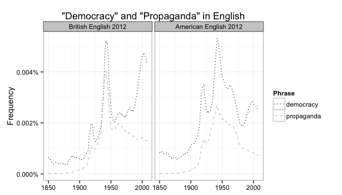

Strikingly, although “propaganda” and “democracy” covary throughout most of this period, a break occurs in American and British English after World War II (and especially beginning in the 1980s) in which the appearance of “propaganda” declines while “democracy” increases. The word “media” however, rises throughout this period. We might hypothesize that “media” effectively becomes a more politically palatable term for the same essential social machinery previously known as propaganda. Needless to say, while the data here are consistent with this hypothesis, they are very far from demonstrating anything in particular.

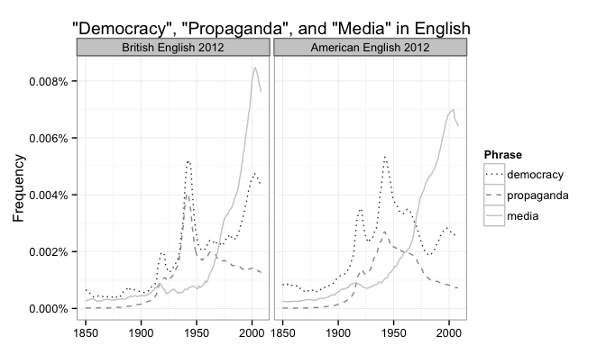

We find a similar pattern in French but with notable differences.

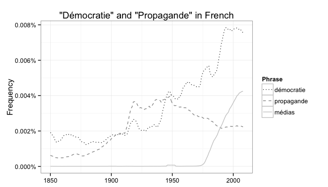

### The Creation of Public Opinion

It is also around this time that the notion of “Public Opinion” gains serious currency, as in the writings of someone such as Walter Lippmann. Specifically, its emergence appears to have relied on the extraordinary success of American and British propaganda during World War I. It only became possible to speak of something called “public opinion” *after* national elites succeeded in using radio and newspapers to hammer millions of diverse hearts and minds into a mass public desire for war against Germany.

It is possible to get the impression today that only in the past few decades has the desire of the masses ever received close, systematic attention from government officials, as if only recently popular sovereignty has become scientific. But the desire of the masses has always been critical in politics, and has always been given close attention. Autocrats have always had to ensure that they not deviate too far from the desire of the masses, because that’s when they get deposed. Public desire has always been important, and has always been studied by the ruling class, as a problem. There is very little evidence for the uncritical assumptions of contemporary political scientists that the study of public opinion is for the purpose of helping government officials better execute the will of the people. Here, interpretation of modern polling data using the language of political radicalism is far more consistent with the historical evidence than “common sense” language: the study of public opinion today is for the purpose of ensuring that the masses never get too angry.

Whenever public opinion falls too low, something can always be done as a response; something to appease the masses and restore their faith in the system. The scientific study of public opinion, however, transforms the desire of the masses into the demands of the masses. And this is why it is one of the most marvelous counterrevolutionary devices ever evolved.

Beginnings:

- Ironically, it was the French Minister of Finance in the years just before the French Revolution who first pointed out the importance of *l’opinion publique*. Jacques Neckar was concerned with what we now call “investor confidence” and he advocated for the publishing of government accounts and policies.
- The Declaration of Independence: The very language of the Declaration of Independence requires that public opinion be taken into account. Our government functions expressly with “the consent of the governed.”
- Abraham Lincoln Said: “What I want to get done is what the people desire to have done, and the question for me is how to find that out exactly.” Lincoln, certainly a President with a less than unanimous approval rating, stated outright his belief in the public mandate. In his case, he used the notion of the will of the people to fight a war.
- Straw Polls: Newspapers often augmented their election coverage by interviewing voters as they left the polling place. These impromptu interviews were called “straw polls,” and the first one recorded in the U.S. took place in 1824. By the turn of the century they were common in both local and national newspapers and magazines.
- Gallup: During the early years of the 20th century the rise of the social sciences in education and government brought sociology and statistics into the public consciousness. Market research firms were born — designed to help manufacturers make and market products of mass appeal. Among the first of the practitioners of scientific polling, George Gallup founded the American Institute of Public Opinion in 1936. He quickly began to apply polling techniques to fields far beyond marketing. Soon after, The Roper and Crossley Poll (FORTUNE Poll) and Harris Poll were also up and running. The National Opinion Research Center was founded in 1941, the first non-commercial polling agency.

Today, the concept of “public opinion,” as it is used by journalists and political scientists, tends to refer to an aggregate variable, a social average, which reflects the ebbs and flows of individuals’ thoughts and attitudes toward some societal issue. Today, we are taught that “public opinion” refers to how the public answers the big social questions which a democratic populace must decide for itself in order to indicate the path politicians must follow. But the history of this concept reveals that, historically, the answer came before the question. At least in its modern founding, the answers of “public opinion” to the most important political questions of the time were quite explicitly decided by state elites *first*; newspapers and radios among other increasingly “mass” media were used to merely pose the right questions.

It is in this time that “propaganda” comes to have a bad name, when Americans and Germans realize they’re both being manipulated. In people like Lippman and Bernays, we observe the high point of unapologetic, unashamed elitism arguing very frankly for elites to use propaganda, via the increasingly “mass” media, to promote their visions of how society should be organized.

To the typical university student today, the connection of these simple facts will sound almost like a conspiracy theory. But if this story sounds like a conspiracy theory, it is not because any of the preceding facts have been contrived or summarized fantastically: it is only because when elites actually organize to manipulate mass publics for their own political purposes, it indeed is something near to an actual conspiracy.[^2]

### Walter Lippmann

Lippmann writes as if the antagonism determined by national geo-politics is more real than the lived relations of human beings. He thinks in all honesty that they were mistaken to have been acting as friends! (Public Opinion, 6).

But isn’t it far more reasonable to say that indeed they were friends, despite the war, because they knew nothing of any reasons to oppose one another? And that it was only the media, which acted as a sort of informational tentacle of the state, which informed them that they should be opposed to one another? The news delivery functioned as a sort of order, and here Lippman testifies to this insofar as he literally attributes the messages of national war propaganda more reality than lived relations.

This is really quite extraordinary! He suggests that there is a real world outside and merely a picture in our heads, but it strikes me as far more reasonable to say that the world we live in with the people around us is the “world outside”" and that newspaper reports of conflicts between nation-states often *literally* only exist as pictures? It is an extremely curious question what permits him such confidence to suggest the opposite, despite the seemingly obvious play in the words here.

One can think of the fidelity of news reports as a distribution (Public Opinion, 15). We tend to think of it as a distribution from “left” to “right” on the traditional partisan political spectrum, but the more interesting distinction to me is the distribution across which a report locates true reality versus a false ideological picture. Obviously this raises very difficult questions about what is truth, but I’m very interested in conceiving news reports to exist on such a spectrum anyway. To my mind, one way to approach this would be to oppose institutional-system causes of problems (probably the truest) vs. other false blame targets which parties on the institutionalized political spectrum agree on. So perhaps we could imagine a true-false distinction orthogonal to the left-right distinction?

Today, it seems to me that we certainly all live in a variously different world in no small part to the explosion of media choice, but the political issue here is very different than what Lippman identified in the 1920s (Public Opinion, 18). It is not that the rich and poor live in different worlds in which they believe the other to be an enemy, it is that they live in different worlds in which they do not see each other as enemies. This strikes me as a remarkable fact today, and it would have to be determined how this came about. One hypothesis might be that the market’s explosion of media choice and advertising’s ability to create various specific identity niches solved the “class war” by simply removing any common ground required for even having any antagonism whatsoever.

What is interesting about Lippman is that he has the honesty to reject the optimism that a “free press” could somehow be a guarantor of society’s larger interests. He says quite frankly that the press cannot be expected to supply the truth about the world, because they are too much determined by precisely the political forces which distort our image of the world (Public Opinion, 26).

### Bell Labs

Bell Labs had its origin in the research laboratory setup by Alexander Graham Bell in 1880 with money he was awarded by the French government for inventing the telephone. The lab was dedicated to the study of sound processing. The modern institution known as Bell Labs was founded in 1925 in the merging of Western Electric’s research department and the engineering department of the American Telephone & Telegraph company (AT&T). Its original main focus was to improve the commercial operation of telephone exchange switches, but with an open-ended agenda for extending the frontiers of human knowledge around information processing in general. They also worked for the US government on commission, such as in Project Nike (1945) to develop anti-aircraft technology and the Apollo Program (1961) which would put the first humans on the moon, but they also did pure scientific research at the forefront of the mathematical sciences. Seven Nobel Prizes in Physics were awarded to Bell Labs Researchers between 1937 and 2009.

The achievements within Bell Labs throughout the twentieth century were extraordinary. Perhaps the largest and most well-funded pursuit of scientific knowledge ever mobilized under one organizational umbrella–driven explicitly by the pursuit of profit and then in cooperation with the interests of state power–had a significant role in almost every technological advancement that marked the twentieth century. In the 1920s, Bell Labs was responsible for the first public demonstration of the fax machine, the first motion picture with sound, the first long-distance transmission of television images. Behind these now well-known consumer technologies, however, were the formal mathematical advancements of which these technologies were only applications. In particular, the mathematical advancements all had to do with the nature of information. Thus, it was also in the 1920s that Bell Labs pioneered the essential concepts of what is now known as “statistical process control,” the mathematical foundations of measuring the stability and efficiency of processes (of an assembly line, for instance) and designed the first ever technically unbreakable cipher.

In 1947, Bell Labs researchers John Bardeen, Walter Brattain invented the transistor, arguably the most important advancement in twentieth-century electronics. William Shockley, also of Bell Labs, is the figure most directly responsible for the commercialization of the transistor. His Shockley Semiconductor Laboratory, established in Mountain View, California, was the epicenter of what would later become known as Silicon Valley. Although his commercial efforts largely failed, several of Shockley’s employees branched out and started more than 60 new enterprises in the same part of California. These enterprises included such names as Intel and ADM. Interestingly, Shockley was also an outspoken racist who believed in eugenics.

It was in 1948 that the Bell Labs Technical Journal published Claude Shannon’s “A Mathematical Theory of Communication”, the founding document of what would come to be known as information theory.

Shannon’s piece is so crucial because it states more exactly than ever before the essential mathematical structure of communication. As Shannon points out, the essence of communication is simply the process of transmitting information from one point to another point. But the defining problem which communication responds to is the fact that the world is composed of “noise,” a variable but always-present background of criss-crossing signals through which purposeful communication has to pass. Go into a silent room and notice that if you listen closely you can always hear a soft hum coming from the world, if only the tiniest vibrations of air in your ear. That’s noise, but it’s relativley little noise, that’s why it’s easy to communicate with someone in such a silent room. If you’re at a music concert and a band is playing, the noise might be so loud that you cannot communicate to anyone at all: this would mean there is so much noise that the signals you’re sending never make it into the other person’s ear. The reason your friend can’t understand you is because your signal is scrambled by the large quantity of other signals in the background.

The formal terms for this essential structure are as follows. An information source produces a message. A transmitter operates on the message to generate a signal. A signal is sent through a channel (with some variable amount of noise). A receiver receives the message and transforms the signal back into a message. Finally, the message arrives at a destination.

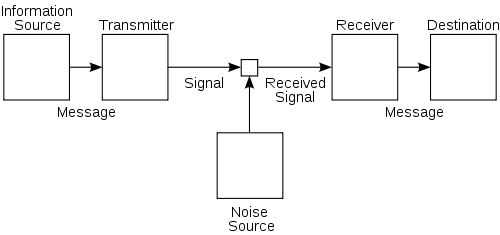

This simple model served as the basis for an extremely sophisticated mathematical development of the nature of communication. The mathematical developments supercharged the rigor and efficiency of a wide variety of real-world endeavours, unsurprisingly centered around maximizing the profits, power, and control of those who put these advancements into practice (indeed “control theory” becomes the literal name of one branch of information theory).

Following Tukey, who used the word in a 1947 Bell Labs internal memo, Shannon deployed the concept of “bit” as the basic unit of information. A bit is simply the amount of information gained when the value of a binary random value (taking the value of either 0 or 1) becomes known. So if there is a 50% chance a coin will land heads rather than tails, and after a flip it indeed lands heads, one bit of information is gleaned.

Shannon is commonly considered the father of the digital revolution because his formalization of the bit as the basic unit of information allowed for more efficient communication, quicker and less noisy than analog.

I think that digitalism is one of the key causal conditions which made possible such a rapid global concentration of economic and political power as the one which began in the 1970s. This marked increase in computational efficiency multiplied the social power of the already dominant institutions, in particular the state and the corporation. And I believe it has led elite social control to a level of stability never before seen in the history of humanity. I think this is one of the most crucial over-arching transformations which characterize the history of most countries in the world from 1970 to today. Needless to say, this remains purely at the level of conjecture and hypothesis. But I think we should see if these theses could be demonstrated.

### The Early Social Science of the Media

From the 1920s until the end of World War II, the conventional wisdom was that the role of mass media in modern society was, and ought to be, an instrument of propaganda for the optimal functioning of the state (Bernays (2004); Lippmann (1922)). At the same time, the war efforts marshalled an extraordinary amount of resources toward increasing elite knowledge of the information and communication sciences. The famous interstate contests of encrypting and deciphering secret codes are perhaps the best known example of this, but the developments in weaponry (for instance, anti-aircraft technology) as well as strategy (game theory) were first and foremost due to advances in the understanding of communication and information. Indeed, the mathematical theory of communication and information, as we will see, was essentially be the basis of the digital revolution and therefore everything we now associate with the information age (Shannon (1948); Gleick (2011)). Quite naturally, the post-war period saw a flowering of social-scientific efforts to link the propaganda role of media to this burgeoning framework of information theory (Wiener 1961; Deutsch 1953; Deutsch 1966; McLuhan 1994; Ellul 1965).[^3] If media were to be tools of propaganda, as many people nearly took for granted, then this new sophistication in the theory of information would make the propaganda function of the media amenable to equally sophisticated social theory and empirical research.

### Norbert Wiener

Norbert Wiener was arguably chief among the towering intellectual figures of the midcentury attempting to understand society with the new tools of information theory. Wiener named the new science “cybernetics,” a term which gained some limited currency at the time but has since fallen into oblivion. Cybernetics was, essentially, an information theory of society: institutions, organizations, and even social systems more generally are machines comparable to mechanic devices. What they all have in common is that their existence is sustained by mechanisms which effectively send signals and respond to signals. The mechanism in an automobile engine which prevents it from overheating is a mechanism which responds to the signal of too much heat, just as the mechanism of elections is supposed to prevent politicians from pursuing unpopular policies. Information theory would allow us to understand political power and social control as essentially, in their most basic units, dynamics of communication.

For Wiener, then, communication and control were the same thing, and he argued passionately that humanity was on the brink of a new age where communication and control would define society: “The thought of every age is reflected in its technique… If the seventeenth and early eighteenth centuries are the age of clocks, and the later eighteenth and nineteenth centuries constitute the age of steam engines, the present time is the age of communication and control.”

But Wiener also wrote passionately and ominously that the American state and small elite minorities posed an extraordinary threat in this new age of communication and control. Starting in World War II and continuing throughout the Cold War, the US state was aggressively bringing science under its aegis. This is well-known and well-documented, but it is especially interesting that it is also reflected in the lives and thought of many of the very towering intellectual figures who were at the forefront of the new sciences. Wiener, for instance, believed firmly in the independent scientist and avoided institutional affiliations, although he did choose to help the war effort in anti-aircraft research. “Without any doubt,” he wrote, “we possess the world’s most highly developed technique of combining the efforts of large numbers of scientists and large quantities of money toward the realization of a single project.” (Wiener 1989, 126).[^4]

### That Social Science is Endogenous to Media

Today, the incipient social-scientific theories of thinkers such as Wiener and McLuhan appear remarkably cynical: given the longstanding conventional wisdom of elites that the media were mere tools of propaganda, the emergence of legitimately scientific models of information quite naturally led social theorists to conceptualize the media as instruments of social control. Thus, these early efforts are laden with surprisingly sinister vocabularies, the most recurring themes revolving around the control, monitoring, and shaping of mass publics.

These early social scientists of the media, most of whom were writing within democratic states, had surprisingly little to say about the media having anything to do with the empowerment of the masses. This is puzzling given that, today, scholars and schoolchildren alike are most immediately inclined to think of the media as a watchdog over government, the main purpose of which is to ensure popular sovereignty through the free flow of information. Today, even those social scientists most critical of media effects are exceptions which prove the rule, as they typically frame their findings as raising questions about the medias well-known function as government watchdog.

If the earliest and most influential social-scientific models of the media were so cynical, then why, when and, how did contemporary social scientists develop such a sanguine view of the media? I do not pretend to offer any definitive answer to such questions, but we ought to float some short and provisional answers to these questions.

Wiener understood the system-level of ideas and communication politics, but he was surprisingly naive to think his ethical arguments could win the day. According to his very outlook, such ideas were like “negative feedback” mechanisms which were purely imaginery: the nervous system he described had to discard that ethical information like our bodies discard germs. For, his ethical critique called into question the very nature of state-and-market-centered political system in the information age.

The extraordinary negative pressures faced by people such as Wiener and Oppenheimer and Einstein when they chose to speak out, is perhaps evidence of the political system’s nervous system neutralizing threats. Oppenheimer’s villainization by the state as a “security threat” and the humiliating trial in front of the House Un-American committee was itself an act of power and control through communication–the public was being told these people and their ethical ideas were bad, i.e. their behavior was being shaped away from such ethical principles. Wiener’s publishers (embodying market forces), put pressure on him to tone down the political sharpness of his perspective,observable in the difference between the first and second editions of *The Human Use of Human Beings*.

But where did our benign democratic notions of the media come from, when for several decades the conventional wisdom on the role of media was expressly anti-democratic and the very nature of information was now becoming understood scientifically? This intersection in intellectual history would seem to predict a future in which the various media would become all the more powerful tools for small national elites to control and manipulate mass publics, the vision largely shared by so many incipient post-war social scientists. But yet, the notion of propaganda recedes from the social sciences from its high point around 1950, while the study of information continues increasing and the social scientific study of media begins in earnest.

In some sense, these social-scientific currents which are only just beginning to theorize the mass media with an emphasis on propaganda and information control are absorbed by government and the private sector. It appears as if this incipient social-scientific perspective is adopted and *put into practice* by various branches of the state, as in the rise of “counterinsurgency” abroad (Carruthers) and government “public relations” at home, or otherwise the private commercial development of communications engineering and “operations management.” As the new sciences of information control are put into practice by the state and the private sector, it is at this time that the curiously mild-mannered attitude toward the media is elevated into a baseline for political science research (Lazarsfeld 1944; Berelson 1954; Campbell et al. 1960).[^5] This baseline conventional wisdom of “limited effects” from media would no doubt be challenged within political science, but it nonetheless has remained dominant (Katz; Bartels 2008). That research funding distributed by the U.S. government and the private sector played a prominent role in the mainstreaming and institutionalization of the Columbia and Michigan models of political science research approaches, at the very same time that information theory is being rapidly mobilized in actual state and corporate operations and logistics, further tempts one to the hypothesis that perhaps the greatest achievement of state and corporate media control was to have ensured that social scientists would never quite succeed in understanding or demonstrating the media’s function in social control.

This is why the present detour through intellectual history is not merely a review of the literature; rather, this sociological review of the literature is itself suggestive empirical evidence, however circumstantial, regarding a crucial transformation in our thinking and practices of media politics. I have traced in the record of the social sciences the transformation of media-as-propaganda to media-as-transparency to outline a general gap in the literature which this volume contributes to filling, but also to present some provisional evidence, very close to home, of precisely how media-as-propaganda may shape certain institutional political outcomes in ways which have hardly been noticed. Indeed, if the media are most importantly propaganda tools then, to the very degree they are politically effective, we would expect them to go unnoticed by institutional social science. Indeed, even the exceptions suggest evidence for this rule, for the most popular intellectual inheritors of the media-as-propaganda tradition today remain marginal to dominant mainstream social science.[^6]

### The Emergence of an Institutionalized Discipline and the Ideology of Limited Effects

Between 1940 and 1960, there was an explosion of research into mass communications. But very different than figures such as Wiener, McLuhan, Luhmann, and the Frankfurt School, the new movement in media research was fundamentally different in its institutional context, its research methods, and ultimately its conclusions. Driven by corporate and government funding, quite naturally it strove toward knowledge that corporations and governments sought.[^7]

In *Personal Influence* (1955, 16-17), Katz and Lazarsfeld inaugurate the “powerful-to-limited effects” narrative of media research which would dominate subsequent political science research on the media. This narrative suggests that the unsophisticated theorists from the previous epoch imagined wrongly that the media has highly potent effects on the attitudes and behaviors of individuals, but that most sophisticated modern researchers find very little evidence of mass communications exerting many direct effects on its audiences. Rather, they suggest that the emerging consensus is that the media are one among many factors that influence individuals in their political attitudes and behaviors. They based their literature review on previous research by Klapper (1950) and Lazarsfeld (1948) but were also influenced heavily by Edward Shils (Pooley 2006).

They themselves are quite fair in acknowledging that possible longer-term, system-level effects of media changes simply require different approaches, but could quite likely represent significant media effects (18-19).

They themselves also point out that the orientation of media research is shaped by the sponsors, who by and large have very specific interests:

> Now of all the different types of effects which have ever been speculated about or categorized, it is safe to say that these sponsors of research–whose goals underlie so much of mass media research–have selected, by and large, just one kind of effect for almost exclusive attention. We are suggesting that the overriding interest of mass media research is in the study of the effectiveness of mass media attempts to influence–usually to change–opinions and attitudes in the very short run.(18-19,24)

“The powerful-to-limited-effects narrative in *Personal Influence*, in turn, was so widely embraced in the late 1950s for a still different set of reasons—because of the scholarly support it lent to the public intellectual defense of American popular culture, in the context of an evolving cold war liberalism (Pooley 2006, 5).”

Klapper’s 1957 review of the literature provides a nice overview of the emerging “limited effects” consensus, which today remains largely the dominant perspective in modern political science research. Klapper’s summary is very similar to the introduction of *Personal Influence,* and provides a good example of how “limited effects” was becoming a template for media scholars.

Interestingly, Klapper himself stresses quite strongly that the media tend to reinforce “existing conditions” (pp. 457).

> Regardless of the condition in question—be it the level of public taste, the tendency of audience members toward or away from delinquent behavior, or their vote intention—and regardless of whether the effect in question be social or individual, the media are more likely to reinforce than to change. (pp. 457-458)

> The now classic *People’s Choice* found reinforcement, or constancy of opinion, approximately ten times as common as con-version among Erie County respondents exposed to the presidential campaign of 1940, and a nine to one ratio was found in the more elaborate study of Elmira voters in 1948. (pp. 6)

#### But reinforcement is not a “limited effect”, it’s system-level convervatism

We come to the realization that latent even in the “limited effects” perspective is already an acknowledgement that mass communications are consistently found to exert status quo bias. This could only be considered a “limited effect” by a marketing executive hoping to convince audiences to buy a new product. What they did not seem to appreciate, and what their political scientists of the “limited effects” school also failed to appreciate, is that consistent reinforcement is actually a very significant political effect. It means that the mass media strengthen any status quo institutional arrangement and its distribution of power: if mass media campaigns to create specific changes consistently failed and rather revealed that mass media tend to reinforced pre-existing atttitudes and behaviors despite their content, the “limited effects” school seems to have rather demonstrated that the mass media have robust effects in convincing people *not to change*. It is no surprise that this implication was left at the laboratory table, and this is why a serious sociological perspective on this literature is so essential: this implication is striking to the critical researcher interested in understanding how unjust and unpopular institutitional arrangements seem so effective in extracting passive consent from the populace, but this observations is not instrumentally valuable to marketers or politicians.

## Phase 2: The Pacification of the World, 1968-Present

These peculiar transformations in social science curiously precede the period of remarkable, worldwide economic integration which has come to be known as globalisation. Globalisation typically refers to the period from the early 1970s to the present, when countries around the world saw large increases in the flows of goods, services, and capital across borders. It is widely thought by political economists that economic integration is welfare-improving on net and in the long-run, yet even staunch free market economists acknowledge that economic integration raises the incomes of certain domestic groups and lowers the incomes of other groups, at least in the short-run. For this reason, globalisation has brought with it many notable examples of political protest and social unrest. Yet, discontent around economic globalisation has varied across time and space and there remains much debate regarding the conditions under which domestic political processes respond to economic globalisation in different ways.

Both the concept and the processes of globalization have had a dubious impact on the popular political imagination. The ideology which this very concept bears witness to is that globalisation is a process, a noun, something which has descended on the system of nation-states from the outside, causing rather than being caused by the actions of policymakers. As such, the very concept represents a political bias because the casting of human actions as a process, the replacement of verbs with nouns ending in “-ation”, is a tendency higlighted by critical discourse analysts of authority figures seeking to obscure the reality of their power [Fowler 1979, 33-41].[^8] It is well documented that politicians strategically deploy the rhetoric of globalization to justify economic reform (Hay 2002), and it has also been shown that the rise of economic globalization weakens the tendency of voters to hold politicians accountable for economic performance (T Hellwig and Samuels 2007; Timothy Hellwig 2007).

Thus, the economics, rhetoric, and politics of economic globalisation since the 1970s appear at first glance quite consistent with the economics, rhetoric, and politics of the media at that time. If the disappearance of propaganda theories during and after the war represented, as I argued above, not the decline of that idea but rather its implementation, then it would stand to reason that the role of media in promoting state interests appears to have played a role in the popular and scholarly narrative of economic globalisation since the 1970s. Specifically, the overarching thesis of this volume–which remains too abstract and provisional to permit rigorous direct testing, but which the present studies begin to make tractable–is that the rise of modern media around the world has, in different ways, helped state elites to promote certain perceptions of international integration to fundamentally undemocratic ends.

### Another way to see the puzzle is to compare globalizations

Another way to look at the puzzle is to consider how, in the first wave of globalization from 1870-1920, there was massive and militant worker resistance. This is the high time of the Second International, militant trade unionism such as the IWW, and sometimes terroristic, organized anarchism. Also great migrations and movement. Today’s globalization is largely a globalization without people, where migration is not nearly as free as it once was (though of course there are what Saskia Sassen calls “counter-geographies” of globalization composed of often illicit population movements), and where worker resistance is not nearly what it was in the previous period most comparable in terms of global economic change. Comparing globalization today with the previous period is another way to motivate the puzzle: if the main precedent for globalization seems to entail massive popular movement of various sorts, how is it that today’s globalization has proceeded without similar popular tumult?

### The False Promise of Non-Profits and “Global Civil Society”

Selznick (1949) is the first definitive work on the notion of co-optation and remains a seminal reference. Cooptation is defined as “the process of absorbing new elements into the leadership or policy-determining structure of an organization as a means of averting threats to its stability or existence.” Formal cooptation is “the sharing of public symbols or administrative burdens of authority and public responsibility, but without an actual transfer of power.”

There is ample evidence that non-profit or “third sector” organizations, even if they begin as visionary and militant activist organiztions seeking to challenge the dominant powers and change the status quo distribution of resources in a fundamental way, are eventually co-opted by those who seek to maintain the status quo. Selznick details at length how this happened to the Tenessee Valley Authority, and even straight-laced hard-nosed public administration scholars today find this process to aptly characterize non-profit policy-making networks (O’Toole and Meier 2004).

The conventional wisdom is that the increasingly networked form of the third-sector is leading to a decentralization of power and therefore a more flexible, open, and ultimately democratic structure. But what O’Toole and Meier show in their quantitative analysis of public school districts in Texas is that non-profit organizations and their newtorks tend to be biased toward the more powerful nodes in their network. Increasing networks do not decentralize or redistribute power more publicly, it merely brings larger swaths of the public into the mainstream policy-making orbit, possibly making them identify with the mainstream policy machine and merely making them complicit and partially responsible for its outcomes, without any change that would represent the network moving correspondingly toward the interests of these newly enfranchised nodes. What they find is that as the network expands, the interests of the most powerful nodes continue to be disproportionately advanced, there is no gain in the interests of the less powerful nodes. No sharing of power, only sharing of responsibility for the policy agenda prefered by the most powerful.

So there’s nothing especially controversial about the claim that non-profit and third-sector organizations are not sectors of social change contesting exploitation and domination by states and corporations so much as they are subsidiary, auxilliary organizations *for* exploitation and domination by states and corporations. This is not a fringe left-wing idea!

But in the 1970s, the process of co-optation goes global on a scale I don’t think we’ve ever seen before. Milton Friedman wins the Nobel Prize in Economics in 1976, after the policies he championed were forced onto the people of Chile and Argentina (by his students) with brutal repression. One year later, Amnesty International wins the Nobel Peace Prize largely for its work on exactly these human rights abuses. The contradiction is extraordinary. (Klein 2010, 118; Letelier 1976)

It seems at this point as if the “international community,” led by Washington, is developing a new type of “social pact.” In the immediate post-war period, the US and the countries of Europe saw strong state investment and state-sponsored provision of public services to complement liberal markets, and the result was (relatively) broadly shared economic growth until the early 1970s. This was widely considered to be kind of grand social bargain between capital and labor, where capital would be relatively free but active, Keynesian government spending would make this an “embedded liberalism” (Ruggie 1982). I think we can seize on the extraordinary irony of the 1976-77 Nobel prizes as marking the public, international debut of a very different social pact with which Washington would seek to replace the Keynesian norm of the liberal democracies.

The bargain was that if leftists and working people around the world acknowledged that neoliberal policy agendas would go forward, then in return leftists would be honored and celebrated and pretty well funded if they limited themselves to merely cleaning up the mess. As long as the leftists didn’t resist the neoliberal policy agenda, they would be given legitimation and funding to do “humanitarian” work. Of course, if they continued with questioning and resisting policy trends, they would be silenced or mocked for their naivete at best (“do you not understand economics!?”), and at worst killed, tortured, etc. In many countries, remember, leftists were literally disappeared, tortured, and killed en masse. At the same time, states around the world, led by institutions such as the IMF and the World Bank and the Nobel, increased funding of the non-profit sector and human rights organizations.

Poeple who came of age after the 1990s tend to think the “third sector” is the sector of people who want to make the world better, the sector of people who reject the pursuit of profit and want to dedicate themselves to helping people. And of course, the people drawn to this sector often are this kind of person. But what they often fail to realize is that this sector has almost nothing to do with social change and almost everything to do with permitting and even empowering the more exploitative state and corporate ventures to which its members are often very opposed. This whole sector is not about social change or making the world better, it is the dried-up carcass of social change. It is what emerged when the masses who rejected exploitation and domination and who once demanded justice and equality were tortured into submission and then offered money and legitimacy in return for keeping quiet.

Thus, it is not only that the third sector is constrained; it is that, because it has evolved out of what states and corporations would permit here and there, it has actually evolved as an auxilliary to their operations. Cleaning up the mess they leave behind to actually protect the state’s and the corporation’s public image.

I would argue this is one of the most important dynamics in the past several decades, for it represents a truly global co-optation on a scale and speed never before seen in the history of the world. It basically folded radical left resistance into capitalism in many (although certainly not all) countries around the world, in the space of only about 20 years (about 1970 to 1990).

1.) The third sector has actually been deployed strategically by governments to distance themselves from responsibility. As O’Toole and Meier explain:

> “An obvious instance in this regard is the response of U.S. governments to the HIV/AIDS problem in the early years of the epidemic. As has been documented in some detail (Shilts 1987), American governments—particularly the national government—were slow to accept the policy and political responsibility for the challenges of HIV/AIDS. The topic was contentious, the solutions not obvious, and the target groups marginalized. The HIV problem chal- lenged the standard approaches favored by public health bureaucracies at all levels of government and exposed the “wicked problem” aspects of the issue. As a consequence, for a number of years key political actors showed little interest in tackling the HIV direct-service challenge di- rectly. Nonetheless, activists and some public health ex- perts pressed the government for action. The upshot was a pattern of indirect government support for a network of (primarily) nonprofit, community-based organizations and related groups. The nongovernmental actors carried the work at the front lines, exposed themselves to direct local visibility and challenge, and advocated for the cause and for the partially disempowered constituencies. Meanwhile, national and most state governments were able to distance themselves from service-provision efforts and the more controversial aspects of public education. Work with gay communities and intravenous drug users was conducted at a distance, with many governments establishing plausible deniability with regard to their own responsibility for what- ever actions were under way.5 The Ryan White Compre- hensive AIDS Resources Emergency Act, passed into law in 1990, formalized the arrangement by setting up a pro- gram of grants to support direct services to community- based HIV organizations, provided those organizations would establish and be advised and overseen by a broad set of community organizations—units with which HIV efforts are presumably interdependent (hospitals, social service organizations, homeless shelters, public health units, and so forth).” (p 683)

2.) The third sector also functions to prevent the “grassroots” from growing too wide and broad-based, because that’s essentially the most dangerous thing in the world for the dominant groups most invested in the status quo. Have you ever seen the film “How to Survive a Plague?” It tells about the history of ACT UP (AIDS Coalition to Unleash Power) and the fight for political acknowledgement of the HIV crisis and the demands for public support in dealing with it. On one hand, it’s inspiring because it’s about how the gay community self-organized creatively and militantly and had much success; but on another hand, something it reveals quite well is that when activists start picking up the slack from a state’s inadequate provision of public services (in this case, essential health services), first of all this process will be biased from the start because the most well-off segments will have more resources and will therefore be over-represented within the movement from the start. Very striking about the film is that this “grassroots” fight against HIV was in large part driven by fairly well-off, often highly educated, mostly white, mostly cis-gendered males. For instance, at one point, they were literally doing their own medical research! This is pretty cool as far as it goes, but the obvious problem is that people with less resources who are often even more vulnerable, such as transgender people or poorer gay people are likely to remain relatively disempowered even within the “grassroots”.

And while it’s not bad in principle for only particular groups to initiate political organizing to save their lives, the real problem is with the state’s institutionalization of these “grassroots” efforts. What happens, as we see today, is that these early inequalities in the “grassroots” are actually aggressively and strategically institutionalized by the state, and the power imbalances early on become rigidly and fatally divisive. Mananzala and Spade (2008) detail at length how the mainstream gay rights movement has reproduced exclusionary and oppressive hierarchies and have failed to represent the interests of the most vulnerable individuals and groups who have equal claim to the banner of LGBTQ. Mainstream LGBTQ organizations in the third sector (and nearly all mainstream organizations seeking to represent any marginalized group) tend to systematically reproduce the hierarchies and inequalites they originally wanted to fight.

But I and many others would argue that this is exactly the function and purpose of the third sector, it’s like a political machine that takes “grassroots” demands for justice and offers to the most privileged members just enough to keep them happy, just enough to make them leave behind those who are worse off than themselves, just enough to keep them from actually disrupting the smooth operation of capital, state power, and the current distribution of wealth and resources.[^9]

This is exactly what folks like Mananzala and Spade (2008) are testifying to and trying to contest. Projects such as the Sylvia Rivera Law Project are an effort to radicalize third-sector politics and subvert these well-known tendencies of status quo organizations. The degree to which this is possible in the long-run is an open question.

# Part 3: Other Topics

### The mythology of press freedom

An longstanding and widespread piece of conventional wisdom is that `freedom of the press" ensures government accountability to the will of the people. This mythology probably derives most importantly from the American revolution. Figures such as Thomas Jefferson were, of course, quite clear in their strong belief that freedom of speech and freedom of the press was absolutely essential for preventing tyranny. While this is almost certainly true, and it seems clear that media freedom plays an important role in promoting certain dimensions of`good governance," such as reducing certain types of corruption (Brunetti and Weber 2003), the more general inference that media freedom keeps governments accountable to popular sovereignty is, as far as I can tell, completely unwarranted by the empirical evidence.

So long as we’re discussing market societies, what is called `freedom of the press" is simply the subordination of information production to the market. In other words, in a capitalist society`freedom of the press" has nothing to do with the liberation of ideas, thinking, expression, or reporting; it is actually quite clearly a matter of *submitting* to a different master. Classic models of state censorship and media control involve a state using force to directly control what gets expressed throughout a society, allowing and promoting those messages which increase the power of the state; the liberal conception of ``freedom of the press" does not involve the *the people* taking this power from the state unto themselves as in the popular ideological fantasy, but rather it is really just a process where the criterion of profitability takes the power of information control from both the state and the people. It is hard to even say that “economic elites” assume the power of information control under liberal press freedom, for the truth is that they have no power other than the superficial and residual power they derive precisely by submitting to the dictates of profitability more subserviently than others.

The real historical problem with classic censorship is not that it tyrannically controls what people think and brainwashes the masses; the problem has only ever been that classic censorship doesn’t work. First, wherever systems of mass censorshp and propaganda have been tried, it has always ended in farce, as the people learn, adapt, and no longer believe anything they hear. This is evidenced in all the famous jokes from the popular culture of the Soviet Union. One could also demonstrate formally that when one person or group controls all channels of communication, even if they always tell the truth, their credibility will be less than if they did not control all the channels of communication. In other words, relinquishing direct control to the market should actually increase the efficacy of government messaging. It makes propaganda possible again, it just becomes propaganda by and for the market. Obviously the market is not an `author" in the sense that economic elites are programming the minds of the masses; but institutions do, at least in their function and effects,`author" ideology if only in the non-controversial sense widely accepted by mainstream social scientists that institutions shape ideas.

In short, the liberal model of freedom of the press is to information what ``floating" exchange rate regimes are to money: a relinquishing of direct control in favor of indirect control and personal enrichment by riding the wave of improved economic efficiency and profitability.

As a side note, it is interesting to connect this to how political scientists today speak of the relationship between public policy and public opinion as ``thermostatic" (Soroka and Wlezien 2005; Wlezien 1995). Public policy responds to public opinion like a thermostat, it is argued, with policymakers increasing policy on certain issues when the public wants more, but then decreasing it if they’ve produced more than the public wants. While this is typically held up as an essentially democratic mechanism, it is also quite literally consistent with Norbert Wiener’s cybernetic dystopian fears of commercia media control (the thermostatic metaphor is first used by Wiener and also mentioned by McLuhan as an example of how media can constitute system-level control mechanisms.)

### Problems with the Opinion-Policy Link

Early, institutionalized, and institutionalizing social scientists had high hopes for using new survey techniques to analyze the individual-level psychological and behavorial processes which constitute modern liberal democracy. Berelson (1952), for instance, notes that democratic theory assumes that citizens meet certain requirements related to tolerance, patience, interest, knowledge, and the will to participate.

But early research in political behavior was extremely bleak: most people had little knowledge of politics, most political opinions were not based on facts, most people were generally authoritarian and prejudiced, they typically only listened to views they already agreed with, and participation in politics was low (Prothro and Grigg 1960; McCloskey 1964; Cobb and Elder 1971, 893). In short, much of this first wave of political science research, largely based on the new survey methods growing popular at the time, would have seemed damning evidence that the citizens of the United States’ simply do not constitute what is called democracy.

Rather than take these studies as ammunition to protest the US political system–and perhaps joining the students, the blacks, and the women who at this very time *were* doing precisely this–the next wave of political scientists simply argued that early theorists of democracy had too narrow a definition of democracy. The new idea was that “democracy” only requires an empirical relationship between public opinion and policymaking *in the aggregate*. If the actual direction of state policymaking were to show zero correlation with shifts in public opinion, this would be damning evidence that what the public wants has no affect on the policies pursued by state elites. But so long as policymaking in general moves in response to aggregate public opinion, this is adequate evidence that the “macropolity” is indeed a functioning democracy. And indeed, since then, political scientists have found that in democracies, shifts in public opinion tend to be followed by corresponding shifts in policymaking. Many scholars interpert these findings as evidence that democratic institutions deliver what they’re supposed to: mass public control over the general direction of national policymaking.

As scholars pointed out even at the time, it is a very conservative move to solve the problem of undemocratic realities by simply weakening the definition of democracy (Easton 1969; Walker 1966; Bachrach 1967). I’m interested in specifying and, in the future, measuring and testing two specific aspects of this politically and therefore scientifically problematic move.

1.) I hypothesize that a crucial unjustified problem at this moment in political science, a theoretical and empirical problem never yet adequately addressed and which bears extraordinary significance for true popular social change, is that *what people express as their opinion is significantly determined by perceived feasibility.* This is probably not a controversial claim and yet this would represent a very serious bias in most public opinion polling. In general, people do not express political demands for policy changes which they believe are impossible given the institutional landscape. Such an articulation is seen as stupid, naive, or simply meaningless, so individuals calculate and articulate their political desires in a way that effectively assumes the institutional status quo *as given*. In this way, discourse on the level of “public opinion” (e.g., asking people questions about what a current government should do) contains an “approval” of the status quo which is not real but is simply assumed into their answer by the nature of the question. Political science since this period essentially imputes to citizens a baseline level of “support” for a status quo which is really nothing more than their degree of capitulation to a status quo which (variably and contingently) presents itself as given and unmovable. These two components–sincere approval of the status quo and mere compliance with power (the very nature of which is to be taken as given)–have never been adequately disaggregated. Public opinion has only ever been, from its beginning, a measured aggregate response to questions which are generated in part by an unmeasured quantum of political force.

In this light, we might begin to hypothesize that political practices such as delegation, the proliferation of subnational and/or supranational bureacracies charged with certain policymaking imperatives and/or prohibitions, have more to do with public opinion than is typically thought. For instance, the European Commission was designed to be the “engine” of European integration precisely because it would be insulated from the snags of domestic resistances. We might hypothesize that the establishment of a bureaucratically insulated policymaking institution such as the EC (or any other sub- or supra-national institution which removes a portion of policymaking power from democratic control) lowers the salience of certain public opinion questions and/or decreases the tendency of citizens to articulate certain approvals or disapprovals. Political scientists such as Timothy Hellwig have shown that citizens do indeed discount their judgments of the political landscape based on exogenous changes such as economic globalization, but this logic ought to apply to any institutional change with any effect on what it is possible for certain actors to do or not do. Specifically, purposeful institutional innovations might have the effect of ameliorating citizens negative judgments of certain actors or other previously existing institutions, or perhaps they might diffuse blame across so many institutions that citizens no longer feel dissatisfied with any of them. More specifically in our example, the advent of the EC might weaken citizens’ negative judgments of domestic policymakers, if they believe domestic policymakers have a weaker institutional role in setting policy than before the advent of the EC.

Researchers will have to disaggregate these “authentic-individual” and “forced-institutional” components of public opinion data before we can take them seriously as reflections of genuine support or disapproval of the political status quo.

2.) Another extraordinary threat to this already conservative rationalization of contemporary public policymaking is the possibility that public opinion is disproportionately shaped by political and economic elites. For, of course, if changes in public opinion were found to be determined by status quo political factors not democratically determined (distinct from and in addition to the baseline bias caused by institutions, outlined above), then even robust correlations between aggregate public opinion and policymaking could no longer be taken seriously as evidence of democracy.

This is the claim of critics such as David Harvey and Naomi Klein. They point to the 1970s as a crucial period. The example of Lewis Powell’s memo to the US Chamber of Commerce (Harvey 2005, 43). The Chamber of Commerce and National Association of Manufacturers began a significant and documented intensification of its spending, lobbying, and membership. The Business Roundtable is founded in 1972. Corporate interests start funding a large group of think-tanks and academic institutions as well. NBER is an example. The Trilateral commission in 1973, the report by political scientists called “The Crisis of Democracy.” Nozick, Milton Freedom on TV. Of course, this remains to be demonstrated very convincingly in the quantitative literature, but I should like to try.

But even the mainstream “public policy” literature testifies to the fact that “political marketing” has as much to do with selling political products, i.e. producing political ideas, as gauging what citizens demand (Lees-Marshment 2011, 9). They quite openly and uncontroversially use techniques of manipulation, taken from advertising and marketing. So it is hardly a fringe left-wing idea that public opinion is the object of politicians’ strategic ouputs as much as it is possibly an input.

### Representations

The overall issue is that mass media representations are shaped in a systematically conservative way–not that they necessarily report on conservative political parties more favorably than leftist parties, although this is how media bias is often conceived.

Rather, the point is that in a capitalist society, media representations will have a conservative bias with respect to the dominant institutions, for example, those institutions which are the common ground of political parties as such. So the issue is not that the media are more or less favorable to left parties or right parties; the issue is that they will not question the legitimacy of political parties *as such*.

So in any patriarchal, white-dominated, capitalist society, the mass media will be sexist, racist, and biased against the critique or protest against capitalism simply because its bias is that it reinforce the hard-wired biases of society (institutions).

#### Stuart Hall video at http://www.youtube.com/watch?v=JsqTXylw-Uo

When right-wing movements emerge, it’s “I might not agree but they are really doing something.”

“Neutrality” is a conservative bias because the “center” is defined by power; as such, it will always be a bit further to the right than the actual centre-point between the interests of all people.

When right-wing phenomena emerge, they might be treated with skepticism but they are acknowledged as existing and their power is affirmed. When left-wing phenomena emerge, it’s childish, idealistic, cunning, manipulative, and ineffective. Comparison of Kingsley Read and the Anti Nazi League is exemplary.

But in doing so, it *makes* the left-wing movement ineffective. And then nothing at all about the local grassroots types of organizing that people of color do by themselves, which are not even newsworthy.

Thus, media simply replicates and thereby reinforces the inherent asymmetry between the forces of right and left. Because it’s always easier to defend that which institutions are aligned on the basis of, and inherently more difficult to argue against that which institutions are invested in, the media simply reflects this and amplifies this.

So it represents the world in a fundamentally conservative way even when it’s balanced and neutral.

Talks about BBC’s principle of neutrality

- When the British National Party emerges, it’s “remarkable” even if dubious
- When the Black Panthers emerged, it’s either not covered or completely demonized
- David Duke, leader of the KKK, wanted by the Home Office and Police as an illegal entrant, given a platform on BBC
- Is Fidel Castro allowed to give a TV speech to the British people?
- In the 1980s there was a lot of blatantly racist media, television and movies etc.
- BBC as respectable and genteel, Lord Reith says what’s wrong with that?

Racist tropes - “They” work too hard - But also “they” are lazy and live off the dole - “They” don’t understand organizing/activism

[output not shown]

#### bell hooks on Madonna

- Started out feminist, but then becomes re-attached to sexism
- bell hooks argues that it’s basically because capitalism requires that you sell yourself
- so she sold the revolutionary feminist until it ran out, then gave into petty stereotypes
- and also sold out black people, calling them the most sexist when she’s being abused by a white man
- hooks argues that it’s because there’s more money to be made on the right than left
- the idea that money is the only value leads women to collude with patriarchy and people of color to collude with racism

#### London Riots Coverage

```
1. Duggan's murder is described as if nothing is known, all awaiting police statements
2. Riots are described as if they were a natural disaster, and then half way through causes are considered
3. Mostly people who condemn the protest, the protest is seen as the problem
4. The actual problem is never even addressed; when it is, it's silenced.
```

### Social Media

1. Everyone knows that social media can and has played a unique role in enabling protest and regime change.
2. This lecture will be about giving you a fuller background for this new and popular issue.
- historical precedents
- variations in success and failure
- variations within success
- why exactly?
1. Many instances where the world wide web was crucial before Arab Spring.
   - first, the EZLN in 1994 before social media
     - talk about this at some length
   - Phillipines 2001
   - Moldova 2009
   - Iran 2009

2004: Facebook invented by Mark Zuckerberg 2005: Youtube invented by Steve Chen and Chad Hurley 2006: Twitter invented 2011: 845 million on FB, 300 million on twitter

FB users in Arab World increased by 78% in 2010, according to Dubai School of Government report cited in Safranek

Phillipines 2001: text messages allowed for a spontaneous protest of more than a million against certain court proceedings against President Estrada. The court reversed its decision and Estrada resigned.

Moldova 2009: after disputed elections, facebook, livejournal and Twitter were used to amplify protests. official media carried no coverage. about 30,000 people. no change of leadership or new election.

Iran 2009: Agha-Soltan shot en route to a government protest. video captured on cell phone, and spread to Youtube, Facebook, and Twitter, launching it to CNN and New York Times. no official media coverage. as for protests, social media mostly used by the west to hear and discuss what was happening in Iran. also, iranian government official actively use internet to disseminate misinformation and religious conservatives are as prominent on twitter as protestors. unsuccessful promoting change.

Tunisia 2010/2011: Bouazizi set himself on fire and video spread by Youtube, protests spread rapidly and Ben Ali fled. Tunisia one of the most connected and educated countries in the Gulf.

Bahrain?

Egypt 2011: Police beat to death Khaled Said. Google exec posted this to Youtube and made a Facebook page.

Libya 2011? Less so. Less tradition of online activism, little web infrastructure.

Why? The basic mechanism is that it lowers socioeconomic barriers to entry into movements, and lowers the transaction costs of sharing this internaitonally (building international support).

References

Adorno, Theodor. 1991. *The Culture Industry: Selected Essays on Mass Culture*. Edited by Jay Bernstein. Abingdon: Routledge.

Berelson, Bernard. 1952. “Democratic Theory and Public Opinion.” *The Public Opinion Quarterly* 16 (3). Oxford University Press on behalf of the American Association for Public Opinion Research: 313–30. doi:10.2307/2745778. http://www.jstor.org/stable/2745778.

Bernays, Edward L. 2004. *Propaganda*. Ig Publishing. http://www.whale.to/b/bernays.pdf.

Brunetti, Aymo, and Beatrice Weber. 2003. “A Free Press Is Bad News for Corruption.” *Journal of Public Economics* 87 (July): 1801–24. http://ac.els-cdn.com.libproxy.temple.edu/S0047272701001864/1-s2.0-S0047272701001864-main.pdf?_tid=75a85ffdb3945f9bfed5f6ffa9e7a0be&acdnat=1334808164_4fe7a11d75ef9c5c93ea3a4ef05f9269.

Debord, Guy. 1967. “The Society of the Spectacle,” 1–64.

Deutsch, Karl W. 1953. *Nationalism and Social Communication : an Inquiry into the Foundations of Nationality*. New York: Technology Press (M.I.T.). http://library.wur.nl/WebQuery/clc/985230.

———. 1966. “The Nerves of Government: Models of Political Communication and Control.”

Ellul, Jacques. 1965. *Propaganda: The Formation of Men’s Attitudes*. New York: Knopf. http://www.getcited.org/pub/101207752.

Gleick, James. 2011. *The Information: A History, a Theory, a Flood*. London: HarperCollins Publishers. http://books.google.co.uk/books?id=CwCHIScqmZsC.

Harvey, David. 2005. *A Brief History of Neoliberalism*. Edited by Oxford University Press. New York: Oxford University Press. http://books.google.com/books?id=F5DZvEVt890C.

Hay, Colin. 2002. “Globalization, European Integration and the Discursive Construction of Economic Imperatives” 9 (2): 147–67.

Hellwig, T, and D Samuels. 2007. “Voting in Open Economies: The Electoral Consequences of Globalization.” *Comparative Political Studies* 40 (3): 283–306. doi:10.1177/0010414006288974. http://cps.sagepub.com/cgi/doi/10.1177/0010414006288974.

Hellwig, Timothy. 2007. “Economic Openness, Policy Uncertainty, and the Dynamics of Government Support.” *Electoral Studies* 26 (4): 772–86. doi:10.1016/j.electstud.2007.06.005. http://linkinghub.elsevier.com/retrieve/pii/S0261379407000510.

Herman, Edward S, and Noam Chomsky. 1988. *Manufacturing Consent: The Political Economy of the Mass Media*. New York: Pantheon.

Horkheimer, Max, and Theodor Adorno. 2009. *Dialectic of Enlightenment*. Stanford, California: Stanford University Press.

Lawson, Chappell H. 2002. *Building the Fourth Estate: Democratization and the Rise of a Free Press in Mexico*. Berkeley: University of California Press.

Lippmann, Walter. 1922. *Public Opinion*. New York: Harcourt, Brace; Company.

Luhmann, Niklas. 2000. *The Reality of the Mass Media*. Stanford University Press. http://books.google.co.uk/books?id=TJVJ\_sUZd48C.

McChesney, Robert. 2000. *Rich Media, Poor Democracy: Communication Politics in Dubious Times*. New Press.

McLuhan, Marshall. 1994. *Understanding Media: The Extensions of Man*. Cambridge, MA: MIT Press. http://scholar.google.com/scholar?q=related:v4yfZiu-4T8J:scholar.google.com/&hl=en&num=20&as_sdt=0,5.

Pinto, J. 2008. “Muzzling the Watchdog: The Case of Disappearing Watchdog Journalism from Argentine Mainstream News.” *Journalism* 9 (6): 750–74.

Shannon, Claude E. 1948. “A Mathematical Theory of Communication.” *The Bell System Technical Journal* 27 (3): 379–423–623–56. doi:10.1002/j.1538-7305.1948.tb01338.x. http://doi.wiley.com/10.1002/j.1538-7305.1948.tb01338.x.

Silverstein, Ken. 2002. “Stop the Press:” *The American Prospect*.

Soroka, Stuart N, and Christopher Wlezien. 2005. “OpinionPolicy Dynamics: Public Preferences and Public Expenditure in the United Kingdom.” *British Journal of Political Science* 35 (04). Cambridge University Press: 665–89. doi:10.1017/S0007123405000347. http://journals.cambridge.org.libproxy.temple.edu/action/displayAbstract?aid=331687.

Wiener, Norbert. 1961. *Cybernetics: or Control and Communication in the Animal and the Machine*. Cambridge, MA: M.I.T. Press. http://books.google.com/books?id=NnM-uISyywAC.

———. 1989. *The Human Use of Human Beings: Cybernetics and Society*. London: Free Association Books.

Wlezien, Christopher. 1995. “The Public as Thermostat: Dynamics of Preferences for Spending.” *American Journal of Political Science* 39 (4): 981.

[^1]: By *system-level political contention* I simply mean public political speech and behavior which challenged the distribution of power and resources at the level of institutions. By institution I only have in mind a basic sociological definition such as any shared understandings, backed by force or not, which effectively structure the behavior of individual agents. In this sense I understand a political or economic *system* to be simply a set of institutions.
[^2]: It would be interesting to trace the history of when and how exactly “conspiracy theory” emerged as a pejorative term to dismiss certain accounts of political history. No doubt there will always exist many truly deranged and unverifiable narratives of political affairs, which are perhaps rightly derided as “conspiracy theories” and rejected. But it also cannot be denied that conspiracies or just conspiratorial tendencies do in fact emerge from time to time in political affairs! And it would seem to me that the pejorative power of the term “conspiracy theory” is itself a little piece of propaganda, as it tends to very successfully neutralize even perfectly true and well-documented narratives of elites engaged in actually sinister behavior! An enterprising student could trace the emergence of this term as a popular notion, when and how it gains its pejorative power and capacity to political neutralize truths about elites which otherwise would indict and threaten their public support.
[^3]: To say nothing of concurrent and parallel movements in radical, continental theory. See Horkheimer and Adorno (2009), Adorno (1991), and Debord (1967).
[^4]: Oppenheimer, a crucial figure in the American development of an atomic bomb, would later speak out against the hydrogen bomb and was aggressively maligned as a “security threat” by the US government and in the mass media. Einstein, as well, was mocked for his critical attitude toward developments in the state’s relationship to science. All of this is to point out that the most towering intellectual figures of this time were beginning to converge on the belief that the institutional dynamics of science were unconscionable.
[^5]: The Columbia group around Lazarsfeld, from the beginning, was really only interested in what was already a highly narrow and market-oriented type of behavioral variation. Bartels notes how they only turned to electoral behavior when they could not find grant money to study consumer behavior (Rossi 1959, 15-16, as cited in Bartels 2008). The point for our purposes is that these pioneering studies which would become baselines for the modern study of political behavior rose to prominence with a view of the media that already abstracted away from the more “sinister” media effects predicted by the group discussed above. Thus, by the 1954 *Voting: A Study of Opinion Formation in a Presidential Campaign,* the Columbia group finds little evidence for the role of parties and media in presidential campaigns. The later Michigan group, whose election studies would become an increasingly institutionalized backbone of American political science research, also had a view of the media which is puzzlingly inane and conservative read alongside work of roughly the same period by someone such as Karl Deutsch. Of course, I do not here take issue with the validity of these early findings as far as they go; my point is only to flag that these foundational studies in American political science adopted an approach which generated strikingly inane findings on the political effects of media, especially when read alongside those who were grappling with the more general historical functions of media as institutions of social control.
[^6]: For instance, see Herman and Chomsky (1988; McChesney 2000; Luhmann 2000)
[^7]: Whether the research agendas arose in response to this elite demand, or this elite interest in media research arose in response to the new research methodologies, is unclear. Obviously both could be the case. They are both separately responses to marked advances in information processing: modern statistical research methods were forged with the theoretical and mathematical victories of the war effort just as the post-war communicational activism of the state and corporate sector were. The rise of a government- and corporate-funded institutionalized social science is merely the cooperation of two groups on the same rising tide of power relative to the more ethical classes.
[^8]: Interestingly, it is also a tendency of social scientists (Billig 117).
[^9]: One could model this formally as a kind of price mechanism. I’m writing this very quickly so the following is probably not quite right, but basically, if the demand for justice goes up (massive contentiousness which threatens the state), while the supply of actual justice remains constant, the price which the state has to pay the grassroots to remain silent goes up. Alternatively, if the demand for justice is constant but there is a sudden decrease in the supply of it (the juntas, for instance), then the price the state has to pay protestors to remain silent increases this way as well. Thus, the Nobel Prize for Amnesty International right after the Nobel Prize for Milton Friedman and the experiments of the Southern Cone is exactly this: the supply of justice decreased, so they had to be willing to pay more for silence.